# 03_Main_Analysis

UMD

- Metabolites: very similar shape and interpretation as Stanford results: phosphate is positively correlated to first dimension. All other metabolites are confounded between each other. Tyramine and putrescine are correlated to one-another
- Subcommunities: The distinction between lactobacilli and non-lactobacilli is obvious using both first and second dimensions and even 3rd dimension. IV-O.a seems independent of IV-O.b. Recurring correlation between IV-B.b and IV-O.a.
- Both: phosphate is probably correlated to IV-O.b; hippurate is correlated to I and maybe other lactobacilli dominated subcommunities; tyramine and putrescine are correlated to IV-B.b and IV-O.a. Lactate is associated with all textit{Lactobacillus}-dominated subcommunities. Cytosine is associated with CST I in 3-4 dimensions

Correlation circle plot

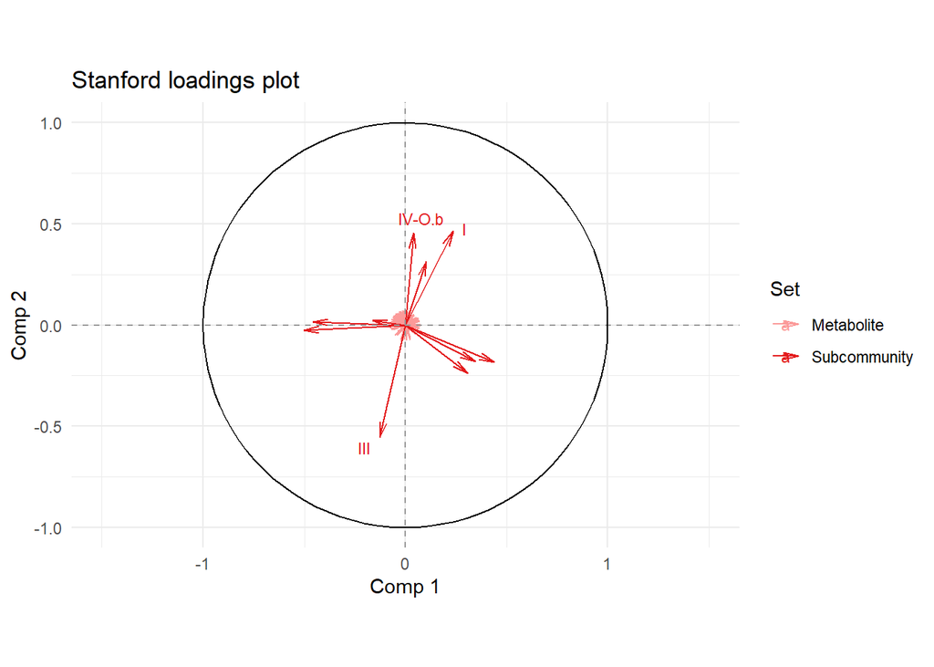

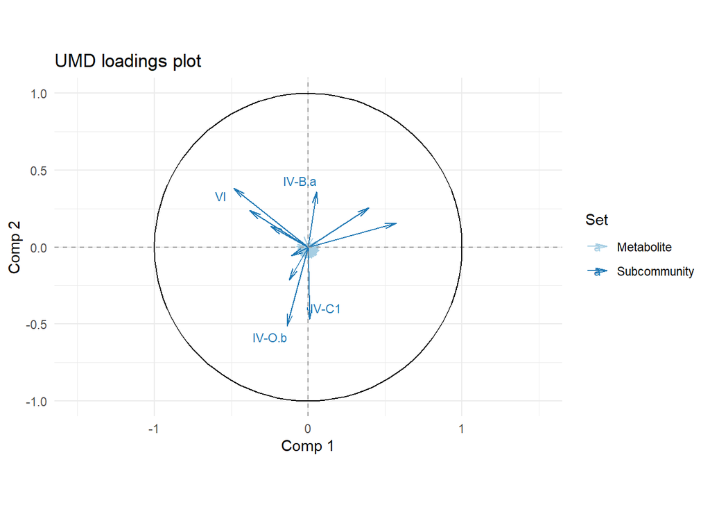

```r
corr.plot(sca.mod = sca.stan, comp = c(1,2), palette = Dcol$Stanford, cohort = "Stanford")
corr.plot(sca.mod = sca.umd, comp = c(1,2), palette = Dcol$UMD, cohort = "UMD")
#corr.plot(sca.mod = sca.stan, comp = c(3,4), palette = Dcol$Stanford, cohort = "Stanford")
#corr.plot(sca.mod = sca.umd, comp = c(3,4), palette = Dcol$UMD, cohort = "UMD")
#multiblock::corrplot(sca.stan, comps = 1:2, labels = F, col = Dcol$Stanford)
#multiblock::corrplot(sca.umd, comps = 1:2, labels = F, col = Dcol$UMD)
#multiblock::corrplot(sca.stan, comps = 3:4, labels = F, col = Dcol$Stanford)
#multiblock::corrplot(sca.umd, comps = 3:4, labels = F, col = Dcol$UMD)
```

The correlation circle plot is essentially a summary of the previous plots where each dot is a variable plotted on given dimensions. The advantage of the correlation circle is that it standardises the distances so as to make the correlations comparable.

In the first two dimensions, the correlation between MB and sub-community variables seem both sparce and low. However, in dimension 3 and 4, the correlations might be more numerous but still low.

## 2.3 Canonical correlation analysis

### 2.3.1 Theory

Canonical correlation analysis is the analysis of the matrix $U=aX$ and $V=bY$ which maximizes the correlation $\rho = corr(U,V)$ such that:

$$\arg \max_{a,b} corr(aX,bY)$$

, where $X$ is $(n\times p)$ and $Y$ is $(n \times q)$. Basically, we look for coefficients $a=(a_1, a_2,...,a_p)$ and $b=(b_1, b_2,..., b_q)$ to form linear combinations $U=aX$ and $V=bY$ of the variables of the two datasets $X$ and $Y$ which maximize a given correlation measure between the two response $U$ and $V$, also named *variates*. There are different correlation measures/ coefficients and one most used is the RV coefficient.

Furthermore, CCA can try and find more than one couple of linear combinations $U_1$ and $V_1$; it can also look for additionnal variates $U_k$ and $V_k$ which also maximize the correlation $\rho_k$. These new variates can be constrained to be perpendicular to the previous computed variates.

The CCA model relies on the assumption of linear relationship between the variables of the datasets.

Issues if the data has more variables than observations. Even though omics data analyses involves high-throughput datasets with the number of variables `p` usually greater than the number of observations `n`, the canonical correlation analysis relies on datasets with dimensions $n \times p$ where $n > p$.

Therefore, we need overcome this obstacle:

- whether by selecting variables prior to cca
- or by using more elaborate techniques such as the ones used by `mixOmics`’s Bioconductor’s package

*Variable selection prior to CCA*

From the metabolite preprocessing, we filtered some columns, therefore the dimensions of the datasets are correct for CCA. No additionnal variable selection is needed. We note that for another filter threshold, one might need to make variable selection prior to CCA.

For the compositional datasets we need to be more careful. Since the compositional data describes the proportion of topics (in columns) for each sample (in rows), the row-wise sum is always 100%. In that case, the row-wise value of any one-column $x_{iJ}$ can be calculated based on the values of the remaining columns such that $x_{iJ}= 1- \sum_{j=1}^{J-1} x_{ij}$. Therefore, there will always be one too many variable in the compositional block.

The question now is “which variable to discard”? Since its information can be derived from the other variables, then one could simply choose at random. Or, one might be interested some topics more than others. For example, topics I, II, III, V and VI are all lactobacilli dominant topics and were defined deliberately. Furthermore, topic IV-O.a and IV-O.b are not very well defined topics, with IV-O.b being the topic corresponding to all species that did not belong in any other ones. Therefore, we are tempted to discard variable for proceed with the analysis.

### 2.3.2 Canonical correlations

And now, a standard CCA can be applied using `cancor()` or `CCA::cc()` functions (in this case, the cc() function is based on cancor and offers more results, thus, we use cc()) (see [ref](https://stats.oarc.ucla.edu/r/dae/canonical-correlation-analysis/) for more information on CCA):

```r
#Renaming
X.stan <- MB.stan
Y.stan <- VM.stan[,colnames(VM.stan)!="IV-O.b"]
cca.stan <- CCA::cc(X = X.stan, Y = Y.stan) #the last column has the least overall percentage --> it practically explains nothing
X.umd <- MB.umd
Y.umd <- VM.umd[,colnames(VM.umd)!="IV-O.b"]
cca.umd <- CCA::cc(X = X.umd, Y = Y.umd)
```

Let’s explore the canonical correlations between the metabolite and sub-community datasets.

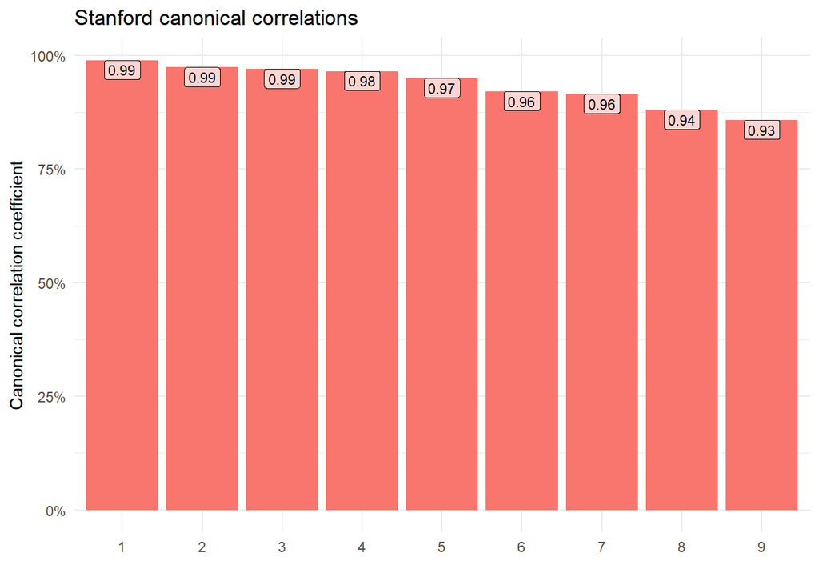

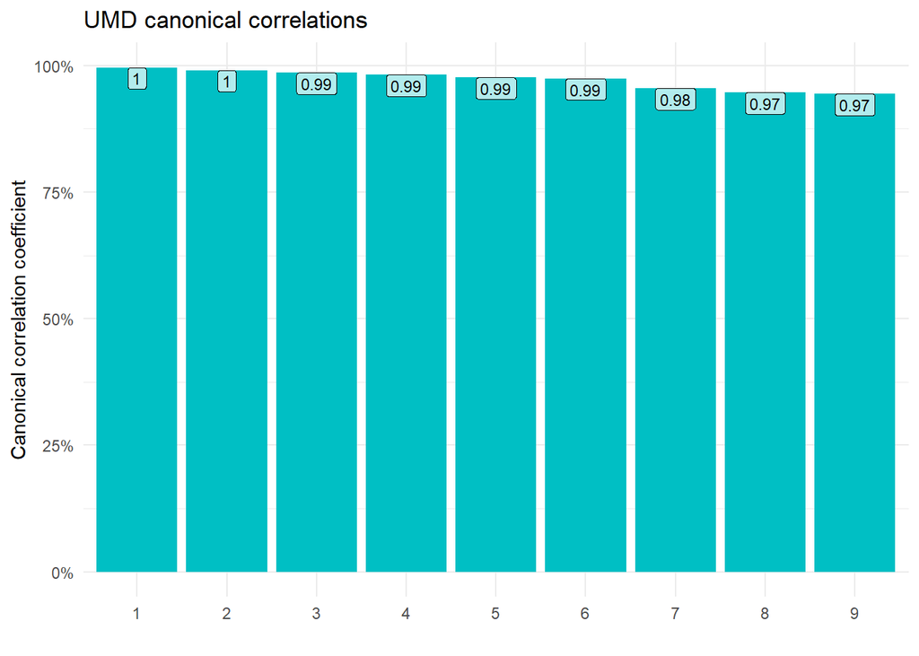

```r
CcaBarplot(cca.stan$cor, cohort = "Stanford", col = CohCol["Stanford"])
CcaBarplot(cca.umd$cor, cohort = "UMD", col = CohCol["UMD"])
```

All canonical correlations $\rho$ are very high (greater than 90%) which means the algorithm was able to find good linear combinations of the variables.

### 2.3.3 Loadings

Next, we’ll use `comput` to compute the loadings of the variables on the canonical dimensions (variates). These loadings are correlations between variables and the canonical variates.

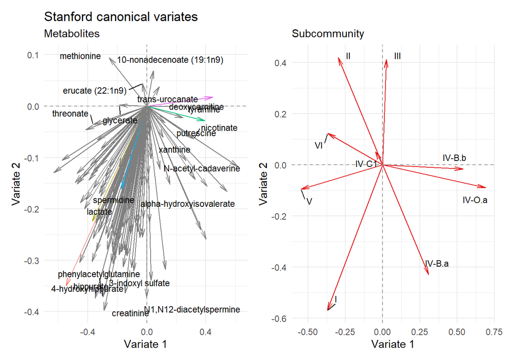

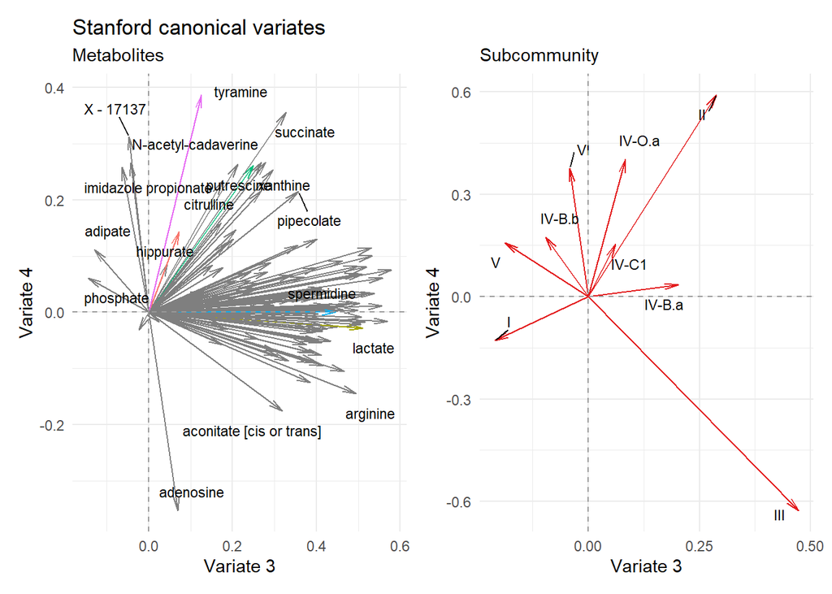

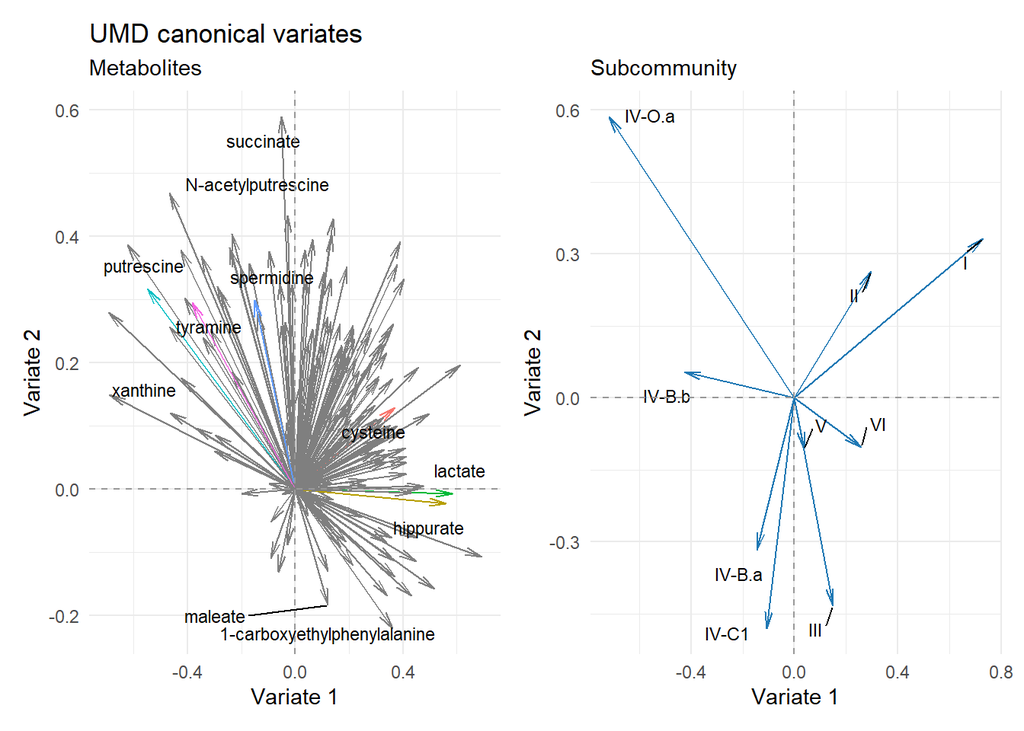

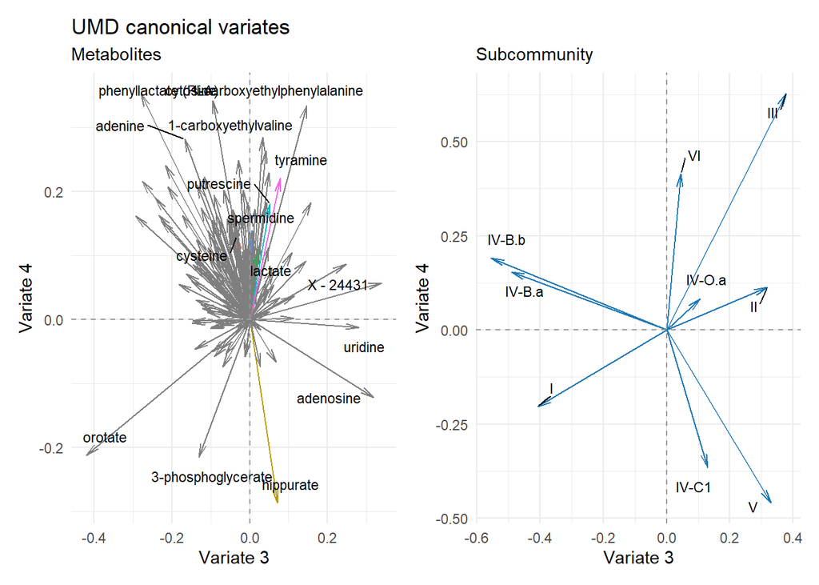

```r
cca.loads(cca.stan, palette = Dcol$Stanford, cohort = "Stanford")
cca.loads(cca.stan, palette = Dcol$Stanford, cohort = "Stanford", comp = c(3,4))
cca.loads(cca.umd, palette = Dcol$UMD, cohort = "UMD")
cca.loads(cca.umd, palette = Dcol$UMD, cohort = "UMD", comp = c(3,4))
```

The previous plots show the contribution of each variable to the variates of their corresponding block. It is important to realize that, for example, *variate 1* of metabolites is not the same as *variate 1* of subcommunities. These two “variate 1” are just highly correlated with one-another.

A naive and simple interpretation of the previous plots could mention that:

- For Stanford, 1) hippurate and ornithine could be associated with subcommunity I; 2) tyramine and putrescine could be associated with IV-O.a; 3) Methionine could be associated with II
- For UMD, 1) Putrescine and tyramine could be associated with IV-O.a; 2) Orotate could be associated with I; 3) Xanthine could be associated with IV-B.b.

One can further these interpretation by focusing on the 8 most contributing variables, in absolute value, of variate 1 for instance. Here are the results:

```r
##### STANFORD - VARIATE 1
rbind(
  data.frame(block = "Metabolites",
             cca.stan$scores$corr.X.yscores,
             variab = rownames(cca.stan$scores$corr.X.yscores)) |>
    tibble(),
  data.frame(block = "Sub-community",
             cca.stan$scores$corr.Y.xscores,
             variab = rownames(cca.stan$scores$corr.Y.xscores)) |>
    tibble()
  ) |>
  group_by(block) |>
  mutate(Abs = abs(X1)) |>
  top_n(Abs, n = 8) |>
  dplyr::select(X1, Abs, variab) |> arrange(block, X1) |>
  pander(caption = "Stanford's 8 most contributing metabolites to variate 1")


##### UMD
rbind(
  data.frame(block = "Metabolites",
             cca.umd$scores$corr.X.yscores,
             variab = rownames(cca.umd$scores$corr.X.yscores)) |>
    tibble(),
  data.frame(block = "Sub-community",
             cca.umd$scores$corr.Y.xscores,
             variab = rownames(cca.umd$scores$corr.Y.xscores)) |>
    tibble()
  ) |>
  group_by(block) |>
  mutate(Abs = abs(X1)) |>
  top_n(Abs, n = 8) |>
  dplyr::select(X1, Abs, variab) |> arrange(block, X1) |>
  pander(caption = "UMD's 8 most contributing metabolites to variate 1")
```

Stanford’s 8 most contributing metabolites to variate 1

| block | X1 | Abs | variab |
| --- | --- | --- | --- |
| Metabolites | -0.6322 | 0.6322 | asparagine |
| Metabolites | -0.5752 | 0.5752 | glycerophosphorylcholine (GPC) |
| Metabolites | -0.5485 | 0.5485 | hippurate |
| Metabolites | -0.4859 | 0.4859 | tryptophan |
| Metabolites | -0.4746 | 0.4746 | maltose |
| Metabolites | -0.4741 | 0.4741 | acetylcarnitine (C2) |
| Metabolites | 0.5438 | 0.5438 | alpha-hydroxyisovalerate |
| Metabolites | 0.6193 | 0.6193 | N-acetyl-cadaverine |
| Sub-community | -0.5487 | 0.5487 | V |
| Sub-community | -0.3711 | 0.3711 | I |
| Sub-community | -0.3699 | 0.3699 | VI |
| Sub-community | -0.2995 | 0.2995 | II |
| Sub-community | -0.04955 | 0.04955 | IV-C1 |
| Sub-community | 0.3083 | 0.3083 | IV-B.a |
| Sub-community | 0.5386 | 0.5386 | IV-B.b |
| Sub-community | 0.6905 | 0.6905 | IV-O.a |

UMD’s 8 most contributing metabolites to variate 1

| block | X1 | Abs | variab |
| --- | --- | --- | --- |
| Metabolites | -0.6948 | 0.6948 | alpha-hydroxyisovalerate |
| Metabolites | -0.6907 | 0.6907 | xanthine |
| Metabolites | -0.6242 | 0.6242 | deoxycarnitine |
| Metabolites | -0.5504 | 0.5504 | putrescine |
| Metabolites | 0.5602 | 0.5602 | hippurate |
| Metabolites | 0.5855 | 0.5855 | lactate |
| Metabolites | 0.6144 | 0.6144 | glycerophosphoglycerol |
| Metabolites | 0.6935 | 0.6935 | asparagine |
| Sub-community | -0.7168 | 0.7168 | IV-O.a |
| Sub-community | -0.4265 | 0.4265 | IV-B.b |
| Sub-community | -0.1462 | 0.1462 | IV-B.a |
| Sub-community | -0.1075 | 0.1075 | IV-C1 |
| Sub-community | 0.1485 | 0.1485 | III |
| Sub-community | 0.2577 | 0.2577 | VI |
| Sub-community | 0.2976 | 0.2976 | II |
| Sub-community | 0.7285 | 0.7285 | I |

For Stanford:

- Asparagine is the most contributing metabolite: when asparagine avarage levels increase, one expects the sub-community V to become more predominant, and the sub-community IV-O.a to decrease in population
- Hippurate is amongst the 8 most contributing metabolites: when the average levels of hippurate increase, one expects the proportion of sub-community I to increase.

For UMD:

- Let us talk about putrescine: when the average levels of putrescine increase, one expects the proportion of IV-O.a to increase as well
- When the average levels of hippurate and lactate increase, one expects the general population of textit{Lactobacillus} to increase.

One could repeat such a procedure with the other variates.

In general, the number of canonical dimensions is equal to the number of variables in the smaller set; however, the number of *significant* dimensions may be even smaller. One can test this significance using with texttt{CCP::p.asym()} function. We specify the function to use Wilks’ Lambda for this asymptotic test’ statistics. The test is implemented in such a way that: “the first p-value is calculated including all canonical correlation coefficients, the second p-value is calculated by excluding $\rho_1$, the third p-value is calculated by excluding $\rho_1$ and $\rho_2$ etc., therewith allowing assessment of the statistical significance of each individual correlation coefficient” [url](https://cran.r-project.org/web/packages/CCP/CCP.pdf) d

Therefore, the tests hypothesis are:

$[H_{0,j}: \rho_j=\rho_{j+1} =... = \rho_J = 0]_{j=1,...,J}$

$[H_{1,j}: \exists\ l\ \text{s.t.}\ \rho_l>0]_{j=1,...,J}$

```r
## Calculate p-values using the F-approximations of different test statistics:
p.asym(rho = cca.stan$cor,
       N = nrow(X.stan),
       p = ncol(X.stan),
       q = ncol(Y.stan),
       tstat = "Wilks")
p.asym(rho = cca.umd$cor,
       N = nrow(X.umd),
       p = ncol(X.umd),
       q = ncol(Y.umd),
       tstat = "Wilks")
```

```
## Wilks' Lambda, using F-approximation (Rao's F):
##                  stat   approx  df1      df2      p.value
## 1 to 9:  5.796082e-10 3.875679 1188 475.6704 0.000000e+00
## 2 to 9:  2.848622e-08 3.183337 1048 427.3660 0.000000e+00
## 3 to 9:  5.528500e-07 2.846317  910 377.9157 0.000000e+00
## 4 to 9:  9.548709e-06 2.485843  774 327.3335 0.000000e+00
## 5 to 9:  1.418616e-04 2.105931  640 275.6343 2.780109e-12
## 6 to 9:  1.457620e-03 1.807580  508 222.8341 3.335008e-07
## 7 to 9:  9.635258e-03 1.653946  378 168.9500 1.122472e-04
## 8 to 9:  5.927119e-02 1.417023  250 114.0000 1.755105e-02
## 9 to 9:  2.636283e-01 1.306506  124  58.0000 1.276786e-01
## Wilks' Lambda, using F-approximation (Rao's F):
##                  stat   approx  df1      df2      p.value
## 1 to 9:  3.025656e-13 4.161734 1485 260.6014 0.000000e+00
## 2 to 9:  4.133100e-11 3.404443 1312 236.0222 0.000000e+00
## 3 to 9:  2.283133e-09 2.986544 1141 210.3533 0.000000e+00
## 4 to 9:  8.166243e-08 2.683508  972 183.6038 6.328271e-15
## 5 to 9:  2.275348e-06 2.411160  805 155.7833 8.021028e-11
## 6 to 9:  4.879470e-05 2.175451  640 126.9020 1.358326e-07
## 7 to 9:  9.706124e-04 1.850365  477  96.9706 1.555649e-04
## 8 to 9:  1.112376e-02 1.771439  316  66.0000 2.920755e-03
## 9 to 9:  1.082496e-01 1.784006  157  34.0000 2.464218e-02
```

From the previous tables, we can simply say that all Stanford’s canonical correlations are significantly greater than 0, using a threshold of 5%, except for the last canonical correlation. However, all UMD’s canonical correlations are significant.

## 2.4 PCA on left-joined table

```r
Comb <- cbind(MB.stan, VM.stan)
dim(Comb)
sum(apply(Comb, 2, FUN=sd))
PCA <- multiblock::pca(X = as.matrix(Comb), scale = F, ncomp = 50)
PCA$loadings[,1:2] |> plot(col = as.factor(c(rep("MB", 132), rep("VM", 10))))
PCA$explvar |> barplot()
PCA$scores|>plot()
```

So basically, the SCA function performs a principle component regression with a response variable y based on a random variable `rnorm(nrow(X), mean = 0, sd = 1)`. This PCR is performed by the function `pls::pcr(y ~ X)` where `X` is the input matrix (a combination of all common-row data blocks)

## 2.5 Manual SCA

```r
Smb <- as.matrix(MB.stan) %*% t(as.matrix(MB.stan))
Ssc <- as.matrix(VM.stan) %*% t(as.matrix(VM.stan))

C <- Smb + Ssc
dim(C)
PCA <- FactoMineR::PCA(X = C, scale = FALSE, graph = F)
fviz_eig(PCA, ncp = 30)
fviz_pca_ind(PCA, axes = c(1,2), label = "none")
Score <- PCA$ind$coord

LoadM <- t(MB.stan) %*% Score
LoadS <- t(VM.stan) %*% Score
ggplot()+
  geom_segment(aes(xend = LoadS[,1], yend = LoadS[,2],
                   x = 0, y = 0))
ggplot()+
  geom_segment(aes(xend = LoadM[,1], yend = LoadM[,2],
                   x = 0, y = 0))
```

```r
#STATIS

C <- (statis.stan$RV.eig[1])*Smb + (statis.stan$RV.eig[2])*Ssc
dim(C)

PCA <- FactoMineR::PCA(X = C, scale = FALSE, graph = F)
fviz_eig(PCA, ncp = 30)
fviz_pca_ind(PCA, axes = c(1,2), label = "none")
Score <- PCA$ind$coord

LoadM <- t(MB.stan) %*% Score
LoadS <- t(VM.stan) %*% Score
ggplot()+
  geom_segment(aes(xend = LoadS[,1], yend = LoadS[,2],
                   x = 0, y = 0))
ggplot()+
  geom_segment(aes(xend = LoadM[,1], yend = LoadM[,2],
                   x = 0, y = 0))
```

```r
Smb <- as.matrix(MB.umd) %*% t(as.matrix(MB.umd))
Ssc <- as.matrix(VM.umd) %*% t(as.matrix(VM.umd))

C <- Smb + Ssc
dim(C)
PCA <- FactoMineR::PCA(X = C, scale = FALSE, graph = F)
fviz_eig(PCA, ncp = 30)
fviz_pca_ind(PCA, axes = c(1,2), label = "none")
Score <- PCA$ind$coord

LoadM <- t(MB.umd) %*% Score
LoadS <- t(VM.umd) %*% Score
ggplot()+
  geom_segment(aes(xend = LoadS[,1], yend = LoadS[,2],
                   x = 0, y = 0))
ggplot()+
  geom_segment(aes(xend = LoadM[,1], yend = LoadM[,2],
                   x = 0, y = 0))
```